# Risk Factor Analysis

## Outcome Variable

**Outcome Variable:** ever_stunted

## Predictor Variables

**Intervention Variable:** feducyrs

**Adjustment Set:**

unadjusted

## Stratifying Variables

The analysis was stratified on these variable(s):

- agecat
- studyid
- country

## Data Summary

| agecat | studyid | country | feducyrs | ever_stunted | n_cell | n |
| --- | --- | --- | --- | --- | --- | --- |
| 0-24 months | ki0047075b-MAL-ED | BANGLADESH | Low | 0 | 15 | 149 |
| 0-24 months | ki0047075b-MAL-ED | BANGLADESH | Low | 1 | 25 | 149 |
| 0-24 months | ki0047075b-MAL-ED | BANGLADESH | Medium | 0 | 20 | 149 |
| 0-24 months | ki0047075b-MAL-ED | BANGLADESH | Medium | 1 | 35 | 149 |
| 0-24 months | ki0047075b-MAL-ED | BANGLADESH | High | 0 | 31 | 149 |
| 0-24 months | ki0047075b-MAL-ED | BANGLADESH | High | 1 | 23 | 149 |
| 0-24 months | ki0047075b-MAL-ED | INDIA | Low | 0 | 28 | 147 |
| 0-24 months | ki0047075b-MAL-ED | INDIA | Low | 1 | 31 | 147 |
| 0-24 months | ki0047075b-MAL-ED | INDIA | Medium | 0 | 18 | 147 |
| 0-24 months | ki0047075b-MAL-ED | INDIA | Medium | 1 | 26 | 147 |
| 0-24 months | ki0047075b-MAL-ED | INDIA | High | 0 | 18 | 147 |
| 0-24 months | ki0047075b-MAL-ED | INDIA | High | 1 | 26 | 147 |
| 0-24 months | ki0047075b-MAL-ED | NEPAL | Low | 0 | 16 | 98 |
| 0-24 months | ki0047075b-MAL-ED | NEPAL | Low | 1 | 12 | 98 |
| 0-24 months | ki0047075b-MAL-ED | NEPAL | Medium | 0 | 15 | 98 |
| 0-24 months | ki0047075b-MAL-ED | NEPAL | Medium | 1 | 13 | 98 |
| 0-24 months | ki0047075b-MAL-ED | NEPAL | High | 0 | 32 | 98 |
| 0-24 months | ki0047075b-MAL-ED | NEPAL | High | 1 | 10 | 98 |
| 0-24 months | ki0047075b-MAL-ED | PERU | Low | 0 | 28 | 250 |
| 0-24 months | ki0047075b-MAL-ED | PERU | Low | 1 | 41 | 250 |
| 0-24 months | ki0047075b-MAL-ED | PERU | Medium | 0 | 20 | 250 |
| 0-24 months | ki0047075b-MAL-ED | PERU | Medium | 1 | 41 | 250 |
| 0-24 months | ki0047075b-MAL-ED | PERU | High | 0 | 45 | 250 |
| 0-24 months | ki0047075b-MAL-ED | PERU | High | 1 | 75 | 250 |
| 0-24 months | ki0047075b-MAL-ED | SOUTH AFRICA | Low | 0 | 18 | 110 |
| 0-24 months | ki0047075b-MAL-ED | SOUTH AFRICA | Low | 1 | 19 | 110 |
| 0-24 months | ki0047075b-MAL-ED | SOUTH AFRICA | Medium | 0 | 11 | 110 |
| 0-24 months | ki0047075b-MAL-ED | SOUTH AFRICA | Medium | 1 | 19 | 110 |
| 0-24 months | ki0047075b-MAL-ED | SOUTH AFRICA | High | 0 | 15 | 110 |
| 0-24 months | ki0047075b-MAL-ED | SOUTH AFRICA | High | 1 | 28 | 110 |

[output cut: 330 more lines]

The following strata were considered:

- agecat: 0-24 months, studyid: ki0047075b-MAL-ED, country: BANGLADESH
- agecat: 0-24 months, studyid: ki0047075b-MAL-ED, country: INDIA
- agecat: 0-24 months, studyid: ki0047075b-MAL-ED, country: NEPAL
- agecat: 0-24 months, studyid: ki0047075b-MAL-ED, country: PERU
- agecat: 0-24 months, studyid: ki0047075b-MAL-ED, country: SOUTH AFRICA
- agecat: 0-24 months, studyid: ki0047075b-MAL-ED, country: TANZANIA, UNITED REPUBLIC OF
- agecat: 0-24 months, studyid: ki1000304b-SAS-CompFeed, country: INDIA
- agecat: 0-24 months, studyid: ki1000304b-SAS-FoodSuppl, country: INDIA
- agecat: 0-24 months, studyid: ki1017093b-PROVIDE, country: BANGLADESH
- agecat: 0-24 months, studyid: ki1017093c-NIH-Crypto, country: BANGLADESH
- agecat: 0-24 months, studyid: ki1066203-TanzaniaChild2, country: TANZANIA, UNITED REPUBLIC OF
- agecat: 0-24 months, studyid: ki1113344-GMS-Nepal, country: NEPAL
- agecat: 0-24 months, studyid: ki1119695-PROBIT, country: BELARUS
- agecat: 0-24 months, studyid: ki1126311-ZVITAMBO, country: ZIMBABWE
- agecat: 0-24 months, studyid: ki1135781-COHORTS, country: GUATEMALA
- agecat: 0-24 months, studyid: ki1135781-COHORTS, country: INDIA
- agecat: 0-24 months, studyid: ki1135781-COHORTS, country: PHILIPPINES
- agecat: 0-24 months, studyid: ki1148112-LCNI-5, country: MALAWI
- agecat: 0-24 months, studyid: kiGH5241-JiVitA-3, country: BANGLADESH
- agecat: 0-24 months, studyid: kiGH5241-JiVitA-4, country: BANGLADESH
- agecat: 0-6 months, studyid: ki0047075b-MAL-ED, country: BANGLADESH
- agecat: 0-6 months, studyid: ki0047075b-MAL-ED, country: INDIA
- agecat: 0-6 months, studyid: ki0047075b-MAL-ED, country: NEPAL
- agecat: 0-6 months, studyid: ki0047075b-MAL-ED, country: PERU
- agecat: 0-6 months, studyid: ki0047075b-MAL-ED, country: SOUTH AFRICA
- agecat: 0-6 months, studyid: ki0047075b-MAL-ED, country: TANZANIA, UNITED REPUBLIC OF
- agecat: 0-6 months, studyid: ki1000304b-SAS-CompFeed, country: INDIA
- agecat: 0-6 months, studyid: ki1000304b-SAS-FoodSuppl, country: INDIA
- agecat: 0-6 months, studyid: ki1017093b-PROVIDE, country: BANGLADESH
- agecat: 0-6 months, studyid: ki1017093c-NIH-Crypto, country: BANGLADESH
- agecat: 0-6 months, studyid: ki1066203-TanzaniaChild2, country: TANZANIA, UNITED REPUBLIC OF
- agecat: 0-6 months, studyid: ki1113344-GMS-Nepal, country: NEPAL
- agecat: 0-6 months, studyid: ki1119695-PROBIT, country: BELARUS
- agecat: 0-6 months, studyid: ki1126311-ZVITAMBO, country: ZIMBABWE
- agecat: 0-6 months, studyid: ki1135781-COHORTS, country: GUATEMALA
- agecat: 0-6 months, studyid: ki1135781-COHORTS, country: INDIA
- agecat: 0-6 months, studyid: ki1135781-COHORTS, country: PHILIPPINES
- agecat: 0-6 months, studyid: ki1148112-LCNI-5, country: MALAWI
- agecat: 0-6 months, studyid: kiGH5241-JiVitA-3, country: BANGLADESH
- agecat: 0-6 months, studyid: kiGH5241-JiVitA-4, country: BANGLADESH
- agecat: 6-24 months, studyid: ki0047075b-MAL-ED, country: BANGLADESH
- agecat: 6-24 months, studyid: ki0047075b-MAL-ED, country: INDIA
- agecat: 6-24 months, studyid: ki0047075b-MAL-ED, country: NEPAL
- agecat: 6-24 months, studyid: ki0047075b-MAL-ED, country: PERU
- agecat: 6-24 months, studyid: ki0047075b-MAL-ED, country: SOUTH AFRICA
- agecat: 6-24 months, studyid: ki0047075b-MAL-ED, country: TANZANIA, UNITED REPUBLIC OF
- agecat: 6-24 months, studyid: ki1000304b-SAS-CompFeed, country: INDIA
- agecat: 6-24 months, studyid: ki1000304b-SAS-FoodSuppl, country: INDIA
- agecat: 6-24 months, studyid: ki1017093b-PROVIDE, country: BANGLADESH
- agecat: 6-24 months, studyid: ki1017093c-NIH-Crypto, country: BANGLADESH
- agecat: 6-24 months, studyid: ki1066203-TanzaniaChild2, country: TANZANIA, UNITED REPUBLIC OF
- agecat: 6-24 months, studyid: ki1113344-GMS-Nepal, country: NEPAL
- agecat: 6-24 months, studyid: ki1119695-PROBIT, country: BELARUS
- agecat: 6-24 months, studyid: ki1126311-ZVITAMBO, country: ZIMBABWE
- agecat: 6-24 months, studyid: ki1135781-COHORTS, country: GUATEMALA
- agecat: 6-24 months, studyid: ki1135781-COHORTS, country: INDIA
- agecat: 6-24 months, studyid: ki1135781-COHORTS, country: PHILIPPINES
- agecat: 6-24 months, studyid: ki1148112-LCNI-5, country: MALAWI
- agecat: 6-24 months, studyid: kiGH5241-JiVitA-3, country: BANGLADESH
- agecat: 6-24 months, studyid: kiGH5241-JiVitA-4, country: BANGLADESH

### Dropped Strata

Some strata were dropped due to rare outcomes:

- agecat: 0-24 months, studyid: ki0047075b-MAL-ED, country: TANZANIA, UNITED REPUBLIC OF
- agecat: 0-6 months, studyid: ki0047075b-MAL-ED, country: NEPAL
- agecat: 6-24 months, studyid: ki0047075b-MAL-ED, country: NEPAL
- agecat: 6-24 months, studyid: ki0047075b-MAL-ED, country: TANZANIA, UNITED REPUBLIC OF

## Methods Detail

We’re interested in the causal parameters $E[Y_a]$ for all values of $a \in \mathcal{A}$. These parameters represent the mean outcome if, possibly contrary to fact, we intervened to set all units to have $A=a$. Under the randomization and positivity assumptions, these are identified by the statistical parameters $\psi_a=E_W[E_{Y|A,W}(Y|A=a,W)]$. In addition, we’re interested in the mean of $Y$, $E[Y]$ under no intervention (the observed mean). We will estimate these parameters by using SuperLearner to fit the relevant likelihood factors – $E_{Y|A,W}(Y|A=a,W)$ and $p(A=a|W)$, and then updating our likelihood fit using a joint TMLE.

For unadjusted analyses ($W=\{\}$), initial likelihoods were estimated using Lrnr_glm to estimate the simple $E(Y|A)$ and Lrnr_mean to estimate $p(A)$. For adjusted analyses, a small library containing Lrnr_glmnet, Lrnr_xgboost, and Lrnr_mean was used.

Having estimated these parameters, we will then use the delta method to estimate relative risks and attributable risks relative to a prespecified baseline level of $A$.

# Results Detail

## Results Plots

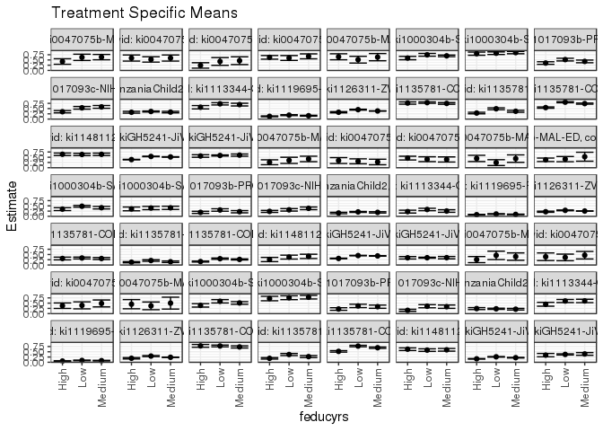

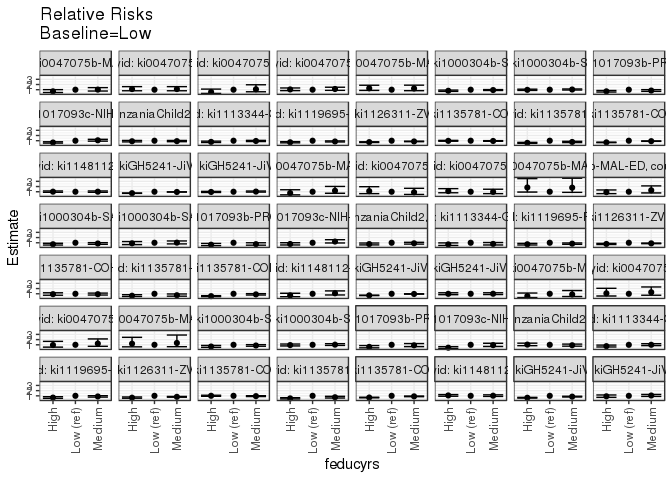

[figure not shown]

[figure not shown]

## Results Table

### Parameter: TSM

| agecat | studyid | country | intervention_level | baseline_level | estimate | ci_lower | ci_upper |
| --- | --- | --- | --- | --- | --- | --- | --- |
| 0-24 months | ki0047075b-MAL-ED | BANGLADESH | Low | NA | 0.6250000 | 0.4744655 | 0.7755345 |
| 0-24 months | ki0047075b-MAL-ED | BANGLADESH | Medium | NA | 0.6363636 | 0.5088034 | 0.7639239 |
| 0-24 months | ki0047075b-MAL-ED | BANGLADESH | High | NA | 0.4259259 | 0.2935940 | 0.5582578 |
| 0-24 months | ki0047075b-MAL-ED | INDIA | Low | NA | 0.5254237 | 0.3975704 | 0.6532771 |
| 0-24 months | ki0047075b-MAL-ED | INDIA | Medium | NA | 0.5909091 | 0.4451370 | 0.7366811 |
| 0-24 months | ki0047075b-MAL-ED | INDIA | High | NA | 0.5909091 | 0.4451370 | 0.7366811 |
| 0-24 months | ki0047075b-MAL-ED | NEPAL | Low | NA | 0.4285714 | 0.2443293 | 0.6128135 |
| 0-24 months | ki0047075b-MAL-ED | NEPAL | Medium | NA | 0.4642857 | 0.2786098 | 0.6499616 |
| 0-24 months | ki0047075b-MAL-ED | NEPAL | High | NA | 0.2380952 | 0.1086231 | 0.3675674 |
| 0-24 months | ki0047075b-MAL-ED | PERU | Low | NA | 0.5942029 | 0.4781073 | 0.7102985 |
| 0-24 months | ki0047075b-MAL-ED | PERU | Medium | NA | 0.6721311 | 0.5540908 | 0.7901715 |
| 0-24 months | ki0047075b-MAL-ED | PERU | High | NA | 0.6250000 | 0.5382073 | 0.7117927 |
| 0-24 months | ki0047075b-MAL-ED | SOUTH AFRICA | Low | NA | 0.5135135 | 0.3517272 | 0.6752998 |
| 0-24 months | ki0047075b-MAL-ED | SOUTH AFRICA | Medium | NA | 0.6333333 | 0.4601036 | 0.8065631 |
| 0-24 months | ki0047075b-MAL-ED | SOUTH AFRICA | High | NA | 0.6511628 | 0.5080583 | 0.7942672 |
| 0-24 months | ki1000304b-SAS-CompFeed | INDIA | Low | NA | 0.7461774 | 0.6806454 | 0.8117094 |
| 0-24 months | ki1000304b-SAS-CompFeed | INDIA | Medium | NA | 0.6960986 | 0.6579970 | 0.7342001 |
| 0-24 months | ki1000304b-SAS-CompFeed | INDIA | High | NA | 0.5912596 | 0.5098374 | 0.6726819 |
| 0-24 months | ki1000304b-SAS-FoodSuppl | INDIA | Low | NA | 0.8231293 | 0.7613743 | 0.8848842 |
| 0-24 months | ki1000304b-SAS-FoodSuppl | INDIA | Medium | NA | 0.8509317 | 0.7958515 | 0.9060118 |
| 0-24 months | ki1000304b-SAS-FoodSuppl | INDIA | High | NA | 0.8000000 | 0.7251603 | 0.8748397 |
| 0-24 months | ki1017093b-PROVIDE | BANGLADESH | Low | NA | 0.5168067 | 0.4532744 | 0.5803390 |
| 0-24 months | ki1017093b-PROVIDE | BANGLADESH | Medium | NA | 0.4304348 | 0.3663994 | 0.4944702 |
| 0-24 months | ki1017093b-PROVIDE | BANGLADESH | High | NA | 0.3534483 | 0.2918910 | 0.4150055 |
| 0-24 months | ki1017093c-NIH-Crypto | BANGLADESH | Low | NA | 0.5371901 | 0.4743275 | 0.6000527 |
| 0-24 months | ki1017093c-NIH-Crypto | BANGLADESH | Medium | NA | 0.5818182 | 0.5165954 | 0.6470410 |
| 0-24 months | ki1017093c-NIH-Crypto | BANGLADESH | High | NA | 0.3513514 | 0.2969306 | 0.4057721 |
| 0-24 months | ki1066203-TanzaniaChild2 | TANZANIA, UNITED REPUBLIC OF | Low | NA | 0.3614173 | 0.3349902 | 0.3878445 |
| 0-24 months | ki1066203-TanzaniaChild2 | TANZANIA, UNITED REPUBLIC OF | Medium | NA | 0.3328313 | 0.2969817 | 0.3686810 |
| 0-24 months | ki1066203-TanzaniaChild2 | TANZANIA, UNITED REPUBLIC OF | High | NA | 0.3251670 | 0.2818292 | 0.3685049 |

[output cut: 138 more lines]

### Parameter: E(Y)

| agecat | studyid | country | intervention_level | baseline_level | estimate | ci_lower | ci_upper |
| --- | --- | --- | --- | --- | --- | --- | --- |
| 0-24 months | ki0047075b-MAL-ED | BANGLADESH | NA | NA | 0.5570470 | 0.4770190 | 0.6370750 |
| 0-24 months | ki0047075b-MAL-ED | INDIA | NA | NA | 0.5646259 | 0.4842023 | 0.6450494 |
| 0-24 months | ki0047075b-MAL-ED | NEPAL | NA | NA | 0.3571429 | 0.2617885 | 0.4524972 |
| 0-24 months | ki0047075b-MAL-ED | PERU | NA | NA | 0.6280000 | 0.5679657 | 0.6880343 |
| 0-24 months | ki0047075b-MAL-ED | SOUTH AFRICA | NA | NA | 0.6000000 | 0.5080312 | 0.6919688 |
| 0-24 months | ki1000304b-SAS-CompFeed | INDIA | NA | NA | 0.6908497 | 0.6505448 | 0.7311545 |
| 0-24 months | ki1000304b-SAS-FoodSuppl | INDIA | NA | NA | 0.8277512 | 0.7915095 | 0.8639929 |
| 0-24 months | ki1017093b-PROVIDE | BANGLADESH | NA | NA | 0.4342857 | 0.3975409 | 0.4710305 |
| 0-24 months | ki1017093c-NIH-Crypto | BANGLADESH | NA | NA | 0.4775726 | 0.4419904 | 0.5131548 |
| 0-24 months | ki1066203-TanzaniaChild2 | TANZANIA, UNITED REPUBLIC OF | NA | NA | 0.3466219 | 0.3275107 | 0.3657331 |
| 0-24 months | ki1113344-GMS-Nepal | NEPAL | NA | NA | 0.6755408 | 0.6380799 | 0.7130017 |
| 0-24 months | ki1119695-PROBIT | BELARUS | NA | NA | 0.1652568 | 0.1463320 | 0.1841817 |
| 0-24 months | ki1126311-ZVITAMBO | ZIMBABWE | NA | NA | 0.3929015 | 0.3847209 | 0.4010821 |
| 0-24 months | ki1135781-COHORTS | GUATEMALA | NA | NA | 0.7672000 | 0.7437624 | 0.7906376 |
| 0-24 months | ki1135781-COHORTS | INDIA | NA | NA | 0.3780235 | 0.3530310 | 0.4030160 |
| 0-24 months | ki1135781-COHORTS | PHILIPPINES | NA | NA | 0.6899306 | 0.6730355 | 0.7068256 |
| 0-24 months | ki1148112-LCNI-5 | MALAWI | NA | NA | 0.6371464 | 0.6040748 | 0.6702180 |
| 0-24 months | kiGH5241-JiVitA-3 | BANGLADESH | NA | NA | 0.4918077 | 0.4839022 | 0.4997131 |
| 0-24 months | kiGH5241-JiVitA-4 | BANGLADESH | NA | NA | 0.5831941 | 0.5609849 | 0.6054033 |
| 0-6 months | ki0047075b-MAL-ED | BANGLADESH | NA | NA | 0.3422819 | 0.2658404 | 0.4187234 |
| 0-6 months | ki0047075b-MAL-ED | INDIA | NA | NA | 0.3061224 | 0.2313639 | 0.3808810 |
| 0-6 months | ki0047075b-MAL-ED | PERU | NA | NA | 0.4280000 | 0.3665434 | 0.4894566 |
| 0-6 months | ki0047075b-MAL-ED | SOUTH AFRICA | NA | NA | 0.3727273 | 0.2819539 | 0.4635007 |
| 0-6 months | ki0047075b-MAL-ED | TANZANIA, UNITED REPUBLIC OF | NA | NA | 0.4009434 | 0.3348159 | 0.4670709 |
| 0-6 months | ki1000304b-SAS-CompFeed | INDIA | NA | NA | 0.4250164 | 0.3969651 | 0.4530677 |
| 0-6 months | ki1000304b-SAS-FoodSuppl | INDIA | NA | NA | 0.3894231 | 0.3425088 | 0.4363374 |
| 0-6 months | ki1017093b-PROVIDE | BANGLADESH | NA | NA | 0.2385714 | 0.2069753 | 0.2701675 |
| 0-6 months | ki1017093c-NIH-Crypto | BANGLADESH | NA | NA | 0.3021108 | 0.2694011 | 0.3348205 |
| 0-6 months | ki1066203-TanzaniaChild2 | TANZANIA, UNITED REPUBLIC OF | NA | NA | 0.1951322 | 0.1792173 | 0.2110471 |
| 0-6 months | ki1113344-GMS-Nepal | NEPAL | NA | NA | 0.2778702 | 0.2420275 | 0.3137129 |
| 0-6 months | ki1119695-PROBIT | BELARUS | NA | NA | 0.0977315 | 0.0847284 | 0.1107345 |
| 0-6 months | ki1126311-ZVITAMBO | ZIMBABWE | NA | NA | 0.2559789 | 0.2486637 | 0.2632941 |
| 0-6 months | ki1135781-COHORTS | GUATEMALA | NA | NA | 0.3196078 | 0.2909760 | 0.3482397 |
| 0-6 months | ki1135781-COHORTS | INDIA | NA | NA | 0.1639690 | 0.1447117 | 0.1832264 |
| 0-6 months | ki1135781-COHORTS | PHILIPPINES | NA | NA | 0.2381944 | 0.2226342 | 0.2537546 |
| 0-6 months | ki1148112-LCNI-5 | MALAWI | NA | NA | 0.3558052 | 0.2982716 | 0.4133389 |
| 0-6 months | kiGH5241-JiVitA-3 | BANGLADESH | NA | NA | 0.4088773 | 0.4013389 | 0.4164158 |
| 0-6 months | kiGH5241-JiVitA-4 | BANGLADESH | NA | NA | 0.3464052 | 0.3252865 | 0.3675239 |
| 6-24 months | ki0047075b-MAL-ED | BANGLADESH | NA | NA | 0.3595506 | 0.2592902 | 0.4598109 |
| 6-24 months | ki0047075b-MAL-ED | INDIA | NA | NA | 0.4042553 | 0.3045164 | 0.5039942 |
| 6-24 months | ki0047075b-MAL-ED | PERU | NA | NA | 0.4132231 | 0.3251210 | 0.5013252 |
| 6-24 months | ki0047075b-MAL-ED | SOUTH AFRICA | NA | NA | 0.4237288 | 0.2965568 | 0.5509008 |
| 6-24 months | ki1000304b-SAS-CompFeed | INDIA | NA | NA | 0.5024631 | 0.4586872 | 0.5462389 |
| 6-24 months | ki1000304b-SAS-FoodSuppl | INDIA | NA | NA | 0.7572016 | 0.7031798 | 0.8112234 |
| 6-24 months | ki1017093b-PROVIDE | BANGLADESH | NA | NA | 0.2997812 | 0.2577294 | 0.3418330 |
| 6-24 months | ki1017093c-NIH-Crypto | BANGLADESH | NA | NA | 0.2628458 | 0.2244546 | 0.3012371 |
| 6-24 months | ki1066203-TanzaniaChild2 | TANZANIA, UNITED REPUBLIC OF | NA | NA | 0.2263323 | 0.2057897 | 0.2468748 |
| 6-24 months | ki1113344-GMS-Nepal | NEPAL | NA | NA | 0.5623529 | 0.5151323 | 0.6095736 |
| 6-24 months | ki1119695-PROBIT | BELARUS | NA | NA | 0.0761786 | 0.0621943 | 0.0901630 |
| 6-24 months | ki1126311-ZVITAMBO | ZIMBABWE | NA | NA | 0.2426433 | 0.2330974 | 0.2521891 |
| 6-24 months | ki1135781-COHORTS | GUATEMALA | NA | NA | 0.7617329 | 0.7327499 | 0.7907158 |
| 6-24 months | ki1135781-COHORTS | INDIA | NA | NA | 0.2663274 | 0.2410848 | 0.2915700 |
| 6-24 months | ki1135781-COHORTS | PHILIPPINES | NA | NA | 0.6482312 | 0.6273346 | 0.6691278 |
| 6-24 months | ki1148112-LCNI-5 | MALAWI | NA | NA | 0.5983027 | 0.5621404 | 0.6344650 |
| 6-24 months | kiGH5241-JiVitA-3 | BANGLADESH | NA | NA | 0.2161949 | 0.2067650 | 0.2256247 |
| 6-24 months | kiGH5241-JiVitA-4 | BANGLADESH | NA | NA | 0.3731683 | 0.3477986 | 0.3985379 |

### Parameter: RR

| agecat | studyid | country | intervention_level | baseline_level | estimate | ci_lower | ci_upper |
| --- | --- | --- | --- | --- | --- | --- | --- |
| 0-24 months | ki0047075b-MAL-ED | BANGLADESH | Low | Low | 1.0000000 | 1.0000000 | 1.0000000 |
| 0-24 months | ki0047075b-MAL-ED | BANGLADESH | Medium | Low | 1.0181818 | 0.7442802 | 1.3928817 |
| 0-24 months | ki0047075b-MAL-ED | BANGLADESH | High | Low | 0.6814815 | 0.4599658 | 1.0096772 |
| 0-24 months | ki0047075b-MAL-ED | INDIA | Low | Low | 1.0000000 | 1.0000000 | 1.0000000 |
| 0-24 months | ki0047075b-MAL-ED | INDIA | Medium | Low | 1.1246334 | 0.7952880 | 1.5903677 |
| 0-24 months | ki0047075b-MAL-ED | INDIA | High | Low | 1.1246334 | 0.7952880 | 1.5903677 |
| 0-24 months | ki0047075b-MAL-ED | NEPAL | Low | Low | 1.0000000 | 1.0000000 | 1.0000000 |
| 0-24 months | ki0047075b-MAL-ED | NEPAL | Medium | Low | 1.0833333 | 0.6022345 | 1.9487609 |
| 0-24 months | ki0047075b-MAL-ED | NEPAL | High | Low | 0.5555556 | 0.2777659 | 1.1111587 |
| 0-24 months | ki0047075b-MAL-ED | PERU | Low | Low | 1.0000000 | 1.0000000 | 1.0000000 |
| 0-24 months | ki0047075b-MAL-ED | PERU | Medium | Low | 1.1311475 | 0.8698132 | 1.4709995 |
| 0-24 months | ki0047075b-MAL-ED | PERU | High | Low | 1.0518293 | 0.8276433 | 1.3367411 |
| 0-24 months | ki0047075b-MAL-ED | SOUTH AFRICA | Low | Low | 1.0000000 | 1.0000000 | 1.0000000 |
| 0-24 months | ki0047075b-MAL-ED | SOUTH AFRICA | Medium | Low | 1.2333333 | 0.8126115 | 1.8718798 |
| 0-24 months | ki0047075b-MAL-ED | SOUTH AFRICA | High | Low | 1.2680539 | 0.8635955 | 1.8619371 |
| 0-24 months | ki1000304b-SAS-CompFeed | INDIA | Low | Low | 1.0000000 | 1.0000000 | 1.0000000 |
| 0-24 months | ki1000304b-SAS-CompFeed | INDIA | Medium | Low | 0.9328862 | 0.8506227 | 1.0231053 |
| 0-24 months | ki1000304b-SAS-CompFeed | INDIA | High | Low | 0.7923848 | 0.6826769 | 0.9197231 |
| 0-24 months | ki1000304b-SAS-FoodSuppl | INDIA | Low | Low | 1.0000000 | 1.0000000 | 1.0000000 |
| 0-24 months | ki1000304b-SAS-FoodSuppl | INDIA | Medium | Low | 1.0337765 | 0.9362525 | 1.1414590 |
| 0-24 months | ki1000304b-SAS-FoodSuppl | INDIA | High | Low | 0.9719008 | 0.8620698 | 1.0957247 |
| 0-24 months | ki1017093b-PROVIDE | BANGLADESH | Low | Low | 1.0000000 | 1.0000000 | 1.0000000 |
| 0-24 months | ki1017093b-PROVIDE | BANGLADESH | Medium | Low | 0.8328738 | 0.6866972 | 1.0101668 |
| 0-24 months | ki1017093b-PROVIDE | BANGLADESH | High | Low | 0.6839080 | 0.5526062 | 0.8464078 |
| 0-24 months | ki1017093c-NIH-Crypto | BANGLADESH | Low | Low | 1.0000000 | 1.0000000 | 1.0000000 |
| 0-24 months | ki1017093c-NIH-Crypto | BANGLADESH | Medium | Low | 1.0830769 | 0.9210456 | 1.2736129 |
| 0-24 months | ki1017093c-NIH-Crypto | BANGLADESH | High | Low | 0.6540541 | 0.5386491 | 0.7941845 |
| 0-24 months | ki1066203-TanzaniaChild2 | TANZANIA, UNITED REPUBLIC OF | Low | Low | 1.0000000 | 1.0000000 | 1.0000000 |
| 0-24 months | ki1066203-TanzaniaChild2 | TANZANIA, UNITED REPUBLIC OF | Medium | Low | 0.9209058 | 0.8084929 | 1.0489487 |
| 0-24 months | ki1066203-TanzaniaChild2 | TANZANIA, UNITED REPUBLIC OF | High | Low | 0.8996996 | 0.7728165 | 1.0474149 |

[output cut: 138 more lines]

### Parameter: PAR

| agecat | studyid | country | intervention_level | baseline_level | estimate | ci_lower | ci_upper |
| --- | --- | --- | --- | --- | --- | --- | --- |
| 0-24 months | ki0047075b-MAL-ED | BANGLADESH | Low | NA | -0.0679530 | -0.1979466 | 0.0620406 |
| 0-24 months | ki0047075b-MAL-ED | INDIA | Low | NA | 0.0392021 | -0.0592497 | 0.1376540 |
| 0-24 months | ki0047075b-MAL-ED | NEPAL | Low | NA | -0.0714286 | -0.2251828 | 0.0823257 |
| 0-24 months | ki0047075b-MAL-ED | PERU | Low | NA | 0.0337971 | -0.0643984 | 0.1319926 |
| 0-24 months | ki0047075b-MAL-ED | SOUTH AFRICA | Low | NA | 0.0864865 | -0.0439917 | 0.2169647 |
| 0-24 months | ki1000304b-SAS-CompFeed | INDIA | Low | NA | -0.0553277 | -0.0928833 | -0.0177721 |
| 0-24 months | ki1000304b-SAS-FoodSuppl | INDIA | Low | NA | 0.0046219 | -0.0448228 | 0.0540667 |
| 0-24 months | ki1017093b-PROVIDE | BANGLADESH | Low | NA | -0.0825210 | -0.1339196 | -0.0311224 |
| 0-24 months | ki1017093c-NIH-Crypto | BANGLADESH | Low | NA | -0.0596175 | -0.1115265 | -0.0077085 |
| 0-24 months | ki1066203-TanzaniaChild2 | TANZANIA, UNITED REPUBLIC OF | Low | NA | -0.0147954 | -0.0326623 | 0.0030714 |
| 0-24 months | ki1113344-GMS-Nepal | NEPAL | Low | NA | -0.0520857 | -0.0948976 | -0.0092738 |
| 0-24 months | ki1119695-PROBIT | BELARUS | Low | NA | -0.0215615 | -0.0336836 | -0.0094394 |
| 0-24 months | ki1126311-ZVITAMBO | ZIMBABWE | Low | NA | -0.0562547 | -0.0746772 | -0.0378323 |
| 0-24 months | ki1135781-COHORTS | GUATEMALA | Low | NA | -0.0176325 | -0.0432367 | 0.0079718 |
| 0-24 months | ki1135781-COHORTS | INDIA | Low | NA | -0.1135019 | -0.1500012 | -0.0770027 |
| 0-24 months | ki1135781-COHORTS | PHILIPPINES | Low | NA | -0.1168327 | -0.1411831 | -0.0924824 |
| 0-24 months | ki1148112-LCNI-5 | MALAWI | Low | NA | 0.0048440 | -0.0395053 | 0.0491932 |
| 0-24 months | kiGH5241-JiVitA-3 | BANGLADESH | Low | NA | -0.0451950 | -0.0529649 | -0.0374251 |
| 0-24 months | kiGH5241-JiVitA-4 | BANGLADESH | Low | NA | -0.0006368 | -0.0135090 | 0.0122353 |
| 0-6 months | ki0047075b-MAL-ED | BANGLADESH | Low | NA | -0.0077181 | -0.1343251 | 0.1188889 |
| 0-6 months | ki0047075b-MAL-ED | INDIA | Low | NA | 0.0010377 | -0.0902348 | 0.0923102 |
| 0-6 months | ki0047075b-MAL-ED | PERU | Low | NA | 0.0222029 | -0.0768685 | 0.1212743 |
| 0-6 months | ki0047075b-MAL-ED | SOUTH AFRICA | Low | NA | 0.1294840 | 0.0088531 | 0.2501150 |
| 0-6 months | ki0047075b-MAL-ED | TANZANIA, UNITED REPUBLIC OF | Low | NA | -0.0088927 | -0.1131510 | 0.0953656 |
| 0-6 months | ki1000304b-SAS-CompFeed | INDIA | Low | NA | -0.0573726 | -0.0974916 | -0.0172536 |
| 0-6 months | ki1000304b-SAS-FoodSuppl | INDIA | Low | NA | -0.0078372 | -0.0717386 | 0.0560642 |
| 0-6 months | ki1017093b-PROVIDE | BANGLADESH | Low | NA | -0.0639496 | -0.1096628 | -0.0182364 |
| 0-6 months | ki1017093c-NIH-Crypto | BANGLADESH | Low | NA | -0.0078065 | -0.0557516 | 0.0401385 |
| 0-6 months | ki1066203-TanzaniaChild2 | TANZANIA, UNITED REPUBLIC OF | Low | NA | -0.0158914 | -0.0307269 | -0.0010560 |
| 0-6 months | ki1113344-GMS-Nepal | NEPAL | Low | NA | -0.0489780 | -0.0909490 | -0.0070071 |
| 0-6 months | ki1119695-PROBIT | BELARUS | Low | NA | -0.0139856 | -0.0237035 | -0.0042677 |
| 0-6 months | ki1126311-ZVITAMBO | ZIMBABWE | Low | NA | -0.0299829 | -0.0466757 | -0.0132902 |
| 0-6 months | ki1135781-COHORTS | GUATEMALA | Low | NA | -0.0137255 | -0.0456347 | 0.0181837 |
| 0-6 months | ki1135781-COHORTS | INDIA | Low | NA | -0.0478214 | -0.0772966 | -0.0183461 |
| 0-6 months | ki1135781-COHORTS | PHILIPPINES | Low | NA | -0.0613225 | -0.0869340 | -0.0357109 |
| 0-6 months | ki1148112-LCNI-5 | MALAWI | Low | NA | -0.0191948 | -0.0915157 | 0.0531262 |
| 0-6 months | kiGH5241-JiVitA-3 | BANGLADESH | Low | NA | -0.0396418 | -0.0475883 | -0.0316953 |
| 0-6 months | kiGH5241-JiVitA-4 | BANGLADESH | Low | NA | -0.0000031 | -0.0130203 | 0.0130141 |
| 6-24 months | ki0047075b-MAL-ED | BANGLADESH | Low | NA | -0.0987828 | -0.2677979 | 0.0702323 |
| 6-24 months | ki0047075b-MAL-ED | INDIA | Low | NA | 0.0431442 | -0.0824406 | 0.1687291 |
| 6-24 months | ki0047075b-MAL-ED | PERU | Low | NA | 0.0192837 | -0.1238952 | 0.1624627 |
| 6-24 months | ki0047075b-MAL-ED | SOUTH AFRICA | Low | NA | 0.0533584 | -0.0846014 | 0.1913183 |
| 6-24 months | ki1000304b-SAS-CompFeed | INDIA | Low | NA | -0.0859723 | -0.1506534 | -0.0212912 |
| 6-24 months | ki1000304b-SAS-FoodSuppl | INDIA | Low | NA | -0.0018345 | -0.0767464 | 0.0730774 |
| 6-24 months | ki1017093b-PROVIDE | BANGLADESH | Low | NA | -0.0671253 | -0.1326105 | -0.0016401 |
| 6-24 months | ki1017093c-NIH-Crypto | BANGLADESH | Low | NA | -0.0897183 | -0.1499943 | -0.0294422 |
| 6-24 months | ki1066203-TanzaniaChild2 | TANZANIA, UNITED REPUBLIC OF | Low | NA | -0.0035113 | -0.0231989 | 0.0161763 |
| 6-24 months | ki1113344-GMS-Nepal | NEPAL | Low | NA | -0.0399862 | -0.0972848 | 0.0173123 |
| 6-24 months | ki1119695-PROBIT | BELARUS | Low | NA | -0.0096170 | -0.0170505 | -0.0021836 |
| 6-24 months | ki1126311-ZVITAMBO | ZIMBABWE | Low | NA | -0.0515202 | -0.0740145 | -0.0290258 |
| 6-24 months | ki1135781-COHORTS | GUATEMALA | Low | NA | -0.0154555 | -0.0471368 | 0.0162258 |
| 6-24 months | ki1135781-COHORTS | INDIA | Low | NA | -0.1025251 | -0.1420771 | -0.0629730 |
| 6-24 months | ki1135781-COHORTS | PHILIPPINES | Low | NA | -0.1238276 | -0.1555449 | -0.0921103 |
| 6-24 months | ki1148112-LCNI-5 | MALAWI | Low | NA | 0.0183027 | -0.0307401 | 0.0673455 |
| 6-24 months | kiGH5241-JiVitA-3 | BANGLADESH | Low | NA | -0.0427795 | -0.0543726 | -0.0311864 |
| 6-24 months | kiGH5241-JiVitA-4 | BANGLADESH | Low | NA | -0.0009625 | -0.0167996 | 0.0148747 |

### Parameter: PAF

| agecat | studyid | country | intervention_level | baseline_level | estimate | ci_lower | ci_upper |
| --- | --- | --- | --- | --- | --- | --- | --- |
| 0-24 months | ki0047075b-MAL-ED | BANGLADESH | Low | NA | -0.1219880 | -0.3828654 | 0.0896750 |
| 0-24 months | ki0047075b-MAL-ED | INDIA | Low | NA | 0.0694303 | -0.1228200 | 0.2287633 |
| 0-24 months | ki0047075b-MAL-ED | NEPAL | Low | NA | -0.2000000 | -0.7194426 | 0.1625193 |
| 0-24 months | ki0047075b-MAL-ED | PERU | Low | NA | 0.0538170 | -0.1164262 | 0.1980999 |
| 0-24 months | ki0047075b-MAL-ED | SOUTH AFRICA | Low | NA | 0.1441441 | -0.1057052 | 0.3375366 |
| 0-24 months | ki1000304b-SAS-CompFeed | INDIA | Low | NA | -0.0800864 | -0.1339772 | -0.0287567 |
| 0-24 months | ki1000304b-SAS-FoodSuppl | INDIA | Low | NA | 0.0055837 | -0.0559852 | 0.0635629 |
| 0-24 months | ki1017093b-PROVIDE | BANGLADESH | Low | NA | -0.1900155 | -0.3154470 | -0.0765442 |
| 0-24 months | ki1017093c-NIH-Crypto | BANGLADESH | Low | NA | -0.1248345 | -0.2394151 | -0.0208465 |
| 0-24 months | ki1066203-TanzaniaChild2 | TANZANIA, UNITED REPUBLIC OF | Low | NA | -0.0426846 | -0.0955316 | 0.0076131 |
| 0-24 months | ki1113344-GMS-Nepal | NEPAL | Low | NA | -0.0771022 | -0.1429092 | -0.0150843 |
| 0-24 months | ki1119695-PROBIT | BELARUS | Low | NA | -0.1304726 | -0.2060166 | -0.0596606 |
| 0-24 months | ki1126311-ZVITAMBO | ZIMBABWE | Low | NA | -0.1431777 | -0.1910882 | -0.0971944 |
| 0-24 months | ki1135781-COHORTS | GUATEMALA | Low | NA | -0.0229829 | -0.0569507 | 0.0098933 |
| 0-24 months | ki1135781-COHORTS | INDIA | Low | NA | -0.3002510 | -0.4017479 | -0.2061032 |
| 0-24 months | ki1135781-COHORTS | PHILIPPINES | Low | NA | -0.1693398 | -0.2062128 | -0.1335940 |
| 0-24 months | ki1148112-LCNI-5 | MALAWI | Low | NA | 0.0076026 | -0.0645055 | 0.0748262 |
| 0-24 months | kiGH5241-JiVitA-3 | BANGLADESH | Low | NA | -0.0918957 | -0.1079439 | -0.0760800 |
| 0-24 months | kiGH5241-JiVitA-4 | BANGLADESH | Low | NA | -0.0010920 | -0.0234064 | 0.0207358 |
| 0-6 months | ki0047075b-MAL-ED | BANGLADESH | Low | NA | -0.0225490 | -0.4681968 | 0.2878295 |
| 0-6 months | ki0047075b-MAL-ED | INDIA | Low | NA | 0.0033898 | -0.3441681 | 0.2610806 |
| 0-6 months | ki0047075b-MAL-ED | PERU | Low | NA | 0.0518759 | -0.2103665 | 0.2573000 |
| 0-6 months | ki0047075b-MAL-ED | SOUTH AFRICA | Low | NA | 0.3473962 | -0.0675051 | 0.6010401 |
| 0-6 months | ki0047075b-MAL-ED | TANZANIA, UNITED REPUBLIC OF | Low | NA | -0.0221794 | -0.3182914 | 0.2074206 |
| 0-6 months | ki1000304b-SAS-CompFeed | INDIA | Low | NA | -0.1349892 | -0.2365353 | -0.0417821 |
| 0-6 months | ki1000304b-SAS-FoodSuppl | INDIA | Low | NA | -0.0201251 | -0.1981587 | 0.1314545 |
| 0-6 months | ki1017093b-PROVIDE | BANGLADESH | Low | NA | -0.2680521 | -0.4741121 | -0.0907965 |
| 0-6 months | ki1017093c-NIH-Crypto | BANGLADESH | Low | NA | -0.0258400 | -0.1974709 | 0.1211915 |
| 0-6 months | ki1066203-TanzaniaChild2 | TANZANIA, UNITED REPUBLIC OF | Low | NA | -0.0814393 | -0.1600552 | -0.0081512 |
| 0-6 months | ki1113344-GMS-Nepal | NEPAL | Low | NA | -0.1762623 | -0.3372497 | -0.0346556 |
| 0-6 months | ki1119695-PROBIT | BELARUS | Low | NA | -0.1431023 | -0.2428813 | -0.0513336 |
| 0-6 months | ki1126311-ZVITAMBO | ZIMBABWE | Low | NA | -0.1171305 | -0.1842616 | -0.0538047 |
| 0-6 months | ki1135781-COHORTS | GUATEMALA | Low | NA | -0.0429448 | -0.1477165 | 0.0522626 |
| 0-6 months | ki1135781-COHORTS | INDIA | Low | NA | -0.2916487 | -0.4826621 | -0.1252438 |
| 0-6 months | ki1135781-COHORTS | PHILIPPINES | Low | NA | -0.2574471 | -0.3693954 | -0.1546505 |
| 0-6 months | ki1148112-LCNI-5 | MALAWI | Low | NA | -0.0539474 | -0.2781675 | 0.1309394 |
| 0-6 months | kiGH5241-JiVitA-3 | BANGLADESH | Low | NA | -0.0969529 | -0.1167065 | -0.0775486 |
| 0-6 months | kiGH5241-JiVitA-4 | BANGLADESH | Low | NA | -0.0000089 | -0.0383018 | 0.0368717 |
| 6-24 months | ki0047075b-MAL-ED | BANGLADESH | Low | NA | -0.2747396 | -0.8470843 | 0.1202562 |
| 6-24 months | ki0047075b-MAL-ED | INDIA | Low | NA | 0.1067251 | -0.2651335 | 0.3692840 |
| 6-24 months | ki0047075b-MAL-ED | PERU | Low | NA | 0.0466667 | -0.3712393 | 0.3372095 |
| 6-24 months | ki0047075b-MAL-ED | SOUTH AFRICA | Low | NA | 0.1259259 | -0.2694922 | 0.3981802 |
| 6-24 months | ki1000304b-SAS-CompFeed | INDIA | Low | NA | -0.1711018 | -0.3071953 | -0.0491771 |
| 6-24 months | ki1000304b-SAS-FoodSuppl | INDIA | Low | NA | -0.0024227 | -0.1064029 | 0.0917853 |
| 6-24 months | ki1017093b-PROVIDE | BANGLADESH | Low | NA | -0.2239143 | -0.4631943 | -0.0237644 |
| 6-24 months | ki1017093c-NIH-Crypto | BANGLADESH | Low | NA | -0.3413341 | -0.5911452 | -0.1307436 |
| 6-24 months | ki1066203-TanzaniaChild2 | TANZANIA, UNITED REPUBLIC OF | Low | NA | -0.0155138 | -0.1063283 | 0.0678460 |
| 6-24 months | ki1113344-GMS-Nepal | NEPAL | Low | NA | -0.0711052 | -0.1783363 | 0.0263676 |
| 6-24 months | ki1119695-PROBIT | BELARUS | Low | NA | -0.1262432 | -0.2327300 | -0.0289550 |
| 6-24 months | ki1126311-ZVITAMBO | ZIMBABWE | Low | NA | -0.2123288 | -0.3085802 | -0.1231571 |
| 6-24 months | ki1135781-COHORTS | GUATEMALA | Low | NA | -0.0202899 | -0.0627815 | 0.0205029 |
| 6-24 months | ki1135781-COHORTS | INDIA | Low | NA | -0.3849588 | -0.5417500 | -0.2441127 |
| 6-24 months | ki1135781-COHORTS | PHILIPPINES | Low | NA | -0.1910239 | -0.2423232 | -0.1418428 |
| 6-24 months | ki1148112-LCNI-5 | MALAWI | Low | NA | 0.0305910 | -0.0549870 | 0.1092272 |
| 6-24 months | kiGH5241-JiVitA-3 | BANGLADESH | Low | NA | -0.1978748 | -0.2524742 | -0.1456555 |
| 6-24 months | kiGH5241-JiVitA-4 | BANGLADESH | Low | NA | -0.0025792 | -0.0459418 | 0.0389857 |